# Visualización I

#### f. Sistemas de coordenadas y facetas

`coord_flip()`: intercambiar ejes

Útil para etiquetas largas en el eje x (como nombres de países).

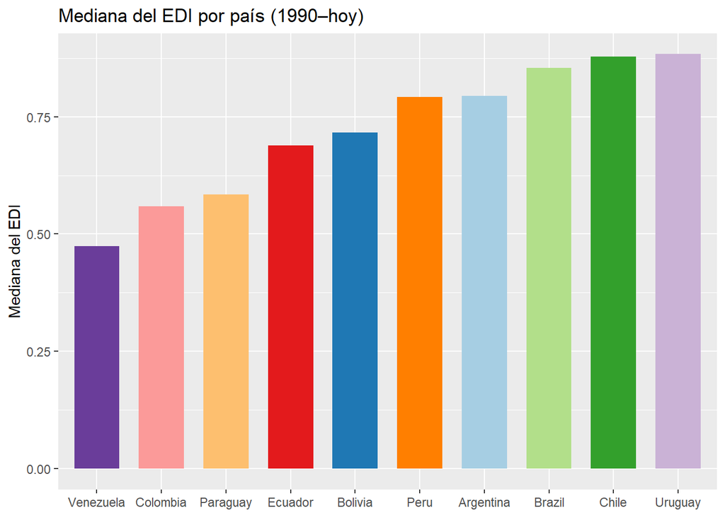

```r
# Mediana del EDI por país en el período democrático reciente
mediana_edi <- sudamerica |>
  filter(year >= 1990) |>
  group_by(pais) |>
  summarise(edi_mediana = median(edi, na.rm = TRUE), .groups = "drop")

ggplot(
    mediana_edi,
    aes(
      x = reorder(pais, edi_mediana), y = edi_mediana, fill = pais
    )
  ) +
  geom_col(show.legend = FALSE, width = 0.7) +
  scale_fill_brewer(palette = "Paired") +
  # coord_flip() +
  labs(
    title = "Mediana del EDI por país (1990–hoy)",
    x = NULL, y = "Mediana del EDI"
  )
```

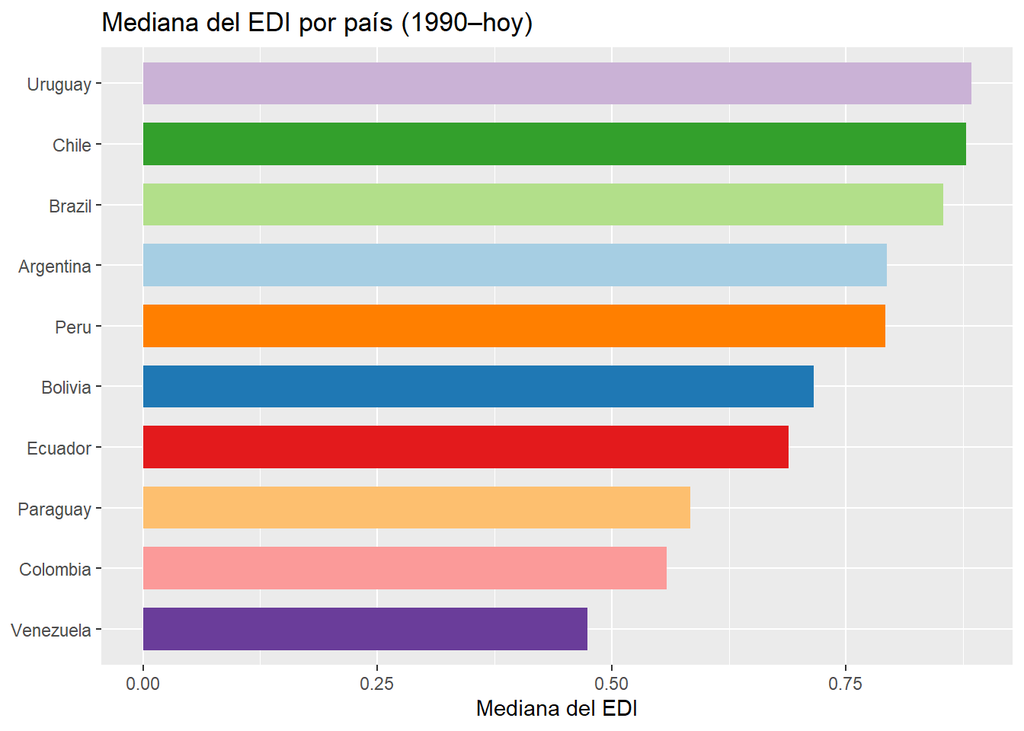

```r
ggplot(
    mediana_edi,
    aes(
      x = reorder(pais, edi_mediana), y = edi_mediana, fill = pais
    )
  ) +
  geom_col(show.legend = FALSE, width = 0.7) +
  scale_fill_brewer(palette = "Paired") +
  coord_flip() +
  labs(
    title = "Mediana del EDI por país (1990–hoy)",
    x = NULL, y = "Mediana del EDI"
  )
```

`facet_wrap()`: dividir por una variable.

Las facetas son una de las herramientas más poderosas de `ggplot2`. Permiten comparar subgrupos manteniendo la misma escala.

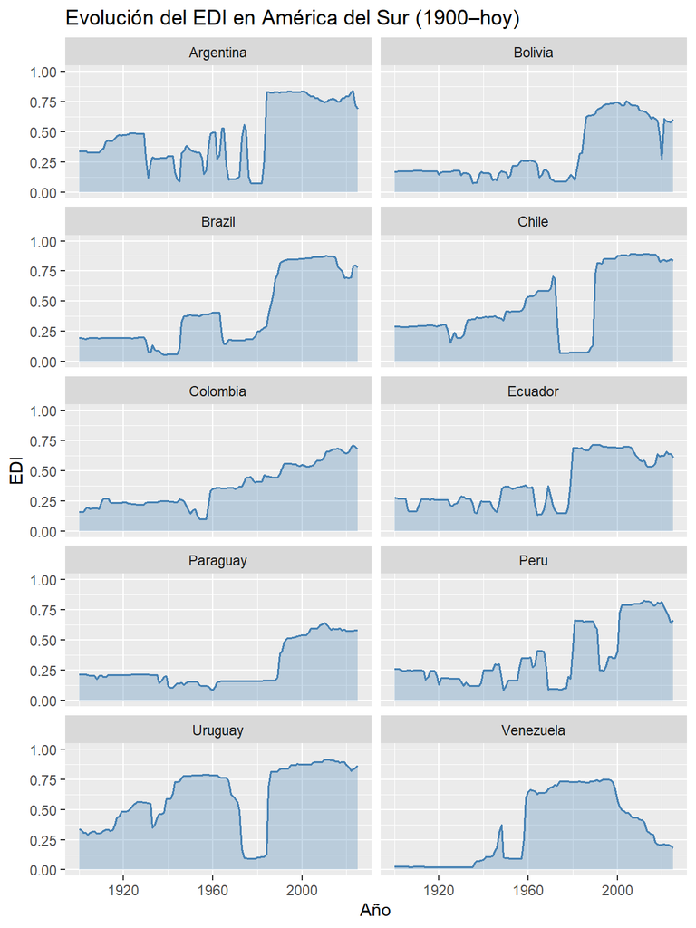

```r
# Una faceta por país, todos con la misma escala en y
ggplot(sudamerica_reciente, aes(x = year, y = edi)) +
  geom_area(fill = "steelblue", alpha = 0.3) +
  geom_line(colour = "steelblue", linewidth = 0.6) +
  facet_wrap(~ pais, ncol = 2) +
  scale_y_continuous(limits = c(0, 1)) +
  labs(
    title = "Evolución del EDI en América del Sur (1900–hoy)",
    x     = "Año",
    y     = "EDI"
  )
```

`facet_wrap()` con escalas libres

A veces queremos ver la *forma* de cada serie sin forzar una escala común. Usamos `scales = "free_y"` para que cada subgráfico tenga su propio eje vertical, `"free_x"` para que cada uno tenga su propio eje horizontal y `"free"` para ambos en simultaneo.

```r
# Los dos índices principales en formato largo (necesario para facetar por índice)
sudamerica_long <- sudamerica_reciente |>
  filter(year >= 1945) |>
  select(pais, year, edi, ldi) |>
  pivot_longer(
    cols = c(edi, ldi),
    names_to  = "indice",
    values_to = "valor"
  ) |>
  mutate(
    indice = recode(indice,
    "edi" = "Democracia Electoral (EDI)",
    "ldi" = "Democracia Liberal (LDI)"
  ))
sudamerica_long
```

| pais | year | indice | valor |
| --- | --- | --- | --- |
| Colombia | 1945 | Democracia Electoral (EDI) | 0.263 |
| Colombia | 1945 | Democracia Liberal (LDI) | 0.200 |
| Colombia | 1946 | Democracia Electoral (EDI) | 0.260 |
| Colombia | 1946 | Democracia Liberal (LDI) | 0.181 |
| Colombia | 1947 | Democracia Electoral (EDI) | 0.250 |
| Colombia | 1947 | Democracia Liberal (LDI) | 0.178 |
| Colombia | 1948 | Democracia Electoral (EDI) | 0.206 |
| Colombia | 1948 | Democracia Liberal (LDI) | 0.152 |
| Colombia | 1949 | Democracia Electoral (EDI) | 0.178 |
| Colombia | 1949 | Democracia Liberal (LDI) | 0.078 |

[output cut: 1610 more lines]

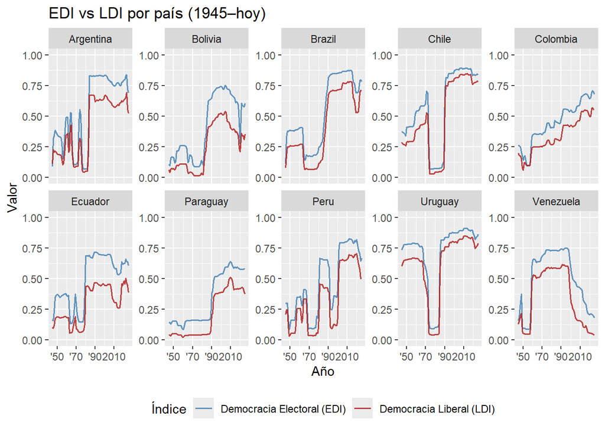

```r
ggplot(sudamerica_long, aes(x = year, y = valor, colour = indice)) +
  geom_line(linewidth = 0.7, alpha = 0.85) +
  facet_wrap(~ pais, ncol = 5, scale="free_y") +
  scale_colour_manual(
    values = c(
      "Democracia Electoral (EDI)" = "steelblue",
      "Democracia Liberal (LDI)"  = "firebrick"
    )
  ) +
  scale_x_continuous(
    breaks = seq(1950, 2020, by = 20), # Forzamos saltos cada 20 años
    labels = c("'50", "'70", "'90", "2010") # Etiquetas cortas para ganar espacio
  ) +
  scale_y_continuous(limits = c(0, 1)) +
  labs(
    title  = "EDI vs LDI por país (1945–hoy)",
    colour = "Índice", x = "Año", y = "Valor"
  ) +
  theme(legend.position = "bottom")
```

`facet_grid()`: cruzar dos variables

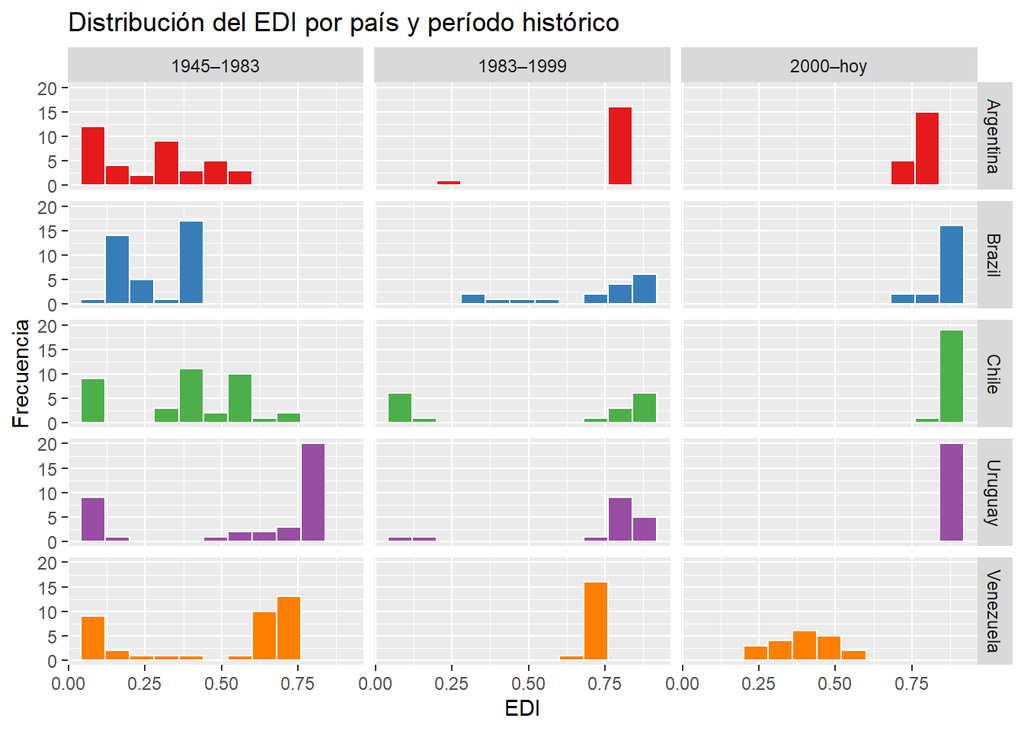

```r
# Dividimos el siglo XX y XXI en períodos históricos
sudamerica_periodos <- sudamerica |>
  filter(year >= 1945) |>
  mutate(
    periodo = case_when(
      year < 1983  ~ "1945–1983",
      year < 2000  ~ "1983–1999",
      TRUE         ~ "2000–hoy"
    )
  ) |>
  filter(pais %in% c("Argentina", "Chile", "Brazil", "Venezuela", "Uruguay"))

# facet_grid: filas = país, columnas = período
ggplot(sudamerica_periodos, aes(x = edi, fill = pais)) +
  geom_histogram(binwidth = 0.08, colour = "white", show.legend = FALSE) +
  facet_grid(pais ~ periodo) +
  scale_fill_brewer(palette = "Set1") +
  labs(
    title = "Distribución del EDI por país y período histórico",
    x     = "EDI", y     = "Frecuencia"
  )
```

### Sobre la composición de gráficos con `patchwork`

`patchwork` permite componer múltiples objetos `ggplot2` en una sola figura usando operadores aritméticos.

| Operador | Acción |
| --- | --- |
| `\\|` | Gráficos lado a lado (misma fila) |
| `/` | Gráficos apilados (misma columna) |
| `+` | Disposición automática |
| `()` | Agrupación para anidamiento |

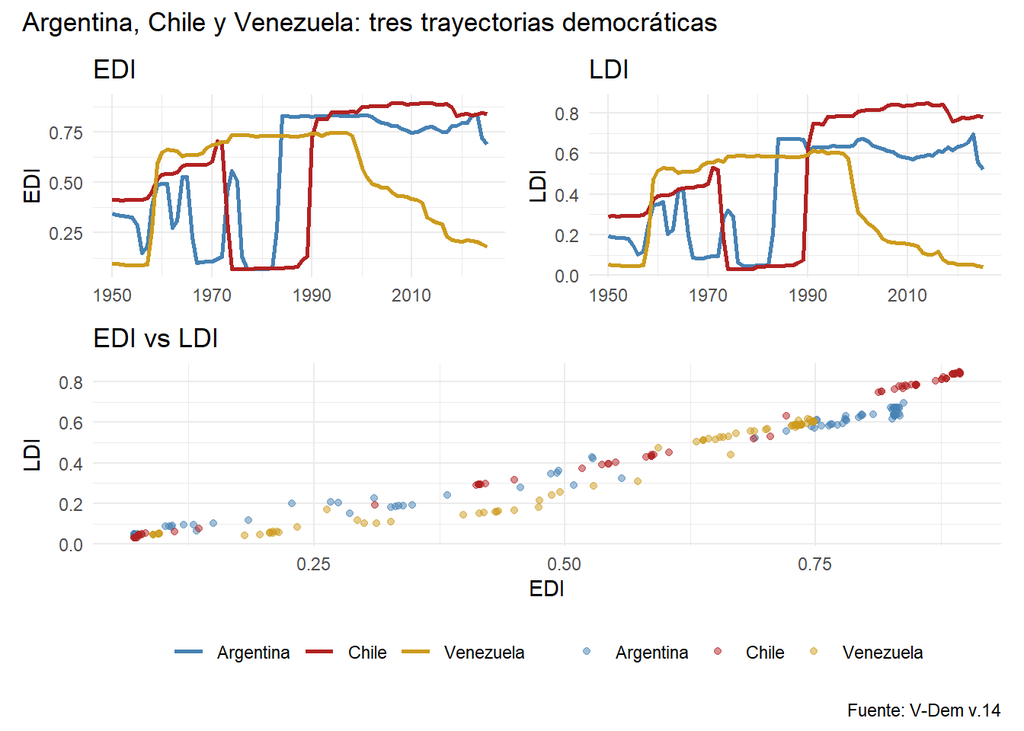

```r
p1 <- ggplot(tres_paises, aes(x = year, y = edi, colour = pais)) +
  geom_line(linewidth = 0.9) +
  scale_colour_manual(values = c("Argentina" = "steelblue",
                                  "Chile"     = "firebrick",
                                  "Venezuela" = "goldenrod3")) +
  labs(title = "EDI", x = NULL, y = "EDI", colour = NULL)

p2 <- ggplot(tres_paises, aes(x = year, y = ldi, colour = pais)) +
  geom_line(linewidth = 0.9) +
  scale_colour_manual(values = c("Argentina" = "steelblue",
                                  "Chile"     = "firebrick",
                                  "Venezuela" = "goldenrod3")) +
  labs(title = "LDI", x = NULL, y = "LDI", colour = NULL)

p3 <- ggplot(tres_paises, aes(x = edi, y = ldi, colour = pais)) +
  geom_point(alpha = 0.5, size = 1.5) +
  scale_colour_manual(values = c("Argentina" = "steelblue",
                                  "Chile"     = "firebrick",
                                  "Venezuela" = "goldenrod3")) +
  labs(title = "EDI vs LDI", x = "EDI", y = "LDI", colour = NULL)

# Composición: p1 y p2 arriba, p3 abajo, y después seguimos apilando capas
(p1 | p2) / p3 +
  plot_layout(guides = "collect") +
  plot_annotation(
    title   = "Argentina, Chile y Venezuela: tres trayectorias democráticas",
    caption = "Fuente: V-Dem v.14"
  ) &
  theme_minimal(base_size = 11) &
  theme(legend.position = "bottom")
```

## Análisis Exploratorio de Datos (EDA) vs. Comunicación

En general, cuando se pretende hacer una visualización se distingue entre

- **EDA (Exploratorio):** el destinatario somos nosotros (quienes hacemos el análisis). El objetivo es *entender* los datos: buscar patrones, anomalías, distribuciones. Muchas veces importa más la velocidad que la estética. Los ejes sin etiquetas, los colores por defecto y el *overplotting* son aceptables porque **el objetivo es el descubrimiento**, no la comunicación.
- **Comunicación****:** el destinatario es otra persona. El objetivo es transmitir un mensaje claro y específico. Cuando comunicamos un gráfico **debe haber una intención clara de lo que se quiere mostrar**. La idea es que todo esté supeditado a esa intención. Cada elemento del gráfico debe justificarse: los títulos guían la interpretación, las paletas son accesibles, la escala es honesta y el ruido visual se elimina.

En los tutoriales, hasta ahora, estuvimos haciendo análisis exploratorio, si bien ciertos gráficos podrían utilizarse para comunicar ideas.

Veamos cómo podría ser un estudio de caso simplificado.

*Supongamos que conocemos los procesos democráticos hasta la década del 90 en latinoamérica (época en la cual terminaron la mayoría de las dictaduras) y, ahora, quisiéramos entender qué pasó de ahí en adelante. En particular, queremos ver si algún país destaca por tener una baja en la participación democrática.*

### El gráfico exploratorio

Hacemos un gráfico simple, pretendiendo tener un primer pantallazo.

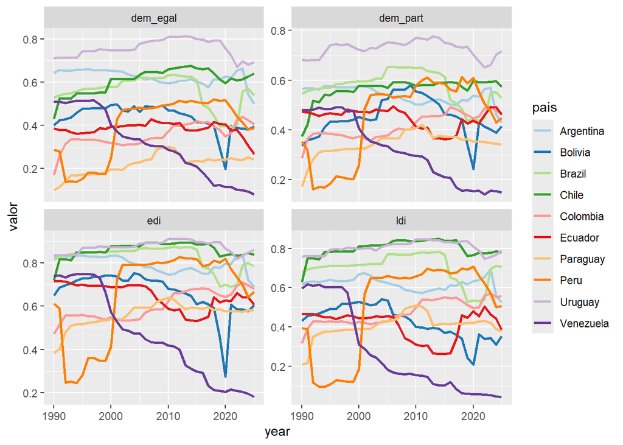

```r
# Gráfico exploratorio rápido: vemos todos los índices disponibles juntos para entender la estructura
sudamerica_long_full <- sudamerica |>
  filter(year >= 1990) |>
  select(pais, year, edi, ldi, dem_part, dem_egal) |>
  pivot_longer(
    cols = c(edi, ldi, dem_part, dem_egal),
    names_to = "indice", values_to = "valor"
  )

# Primera mirada: todos los países, todos los índices
ggplot(
  sudamerica_long_full,
  aes(x = year, y = valor, colour = pais)
  ) +
  facet_wrap(~ indice, ncol = 2, scale="free_y") +
  geom_line(linewidth=1)+
  scale_colour_brewer(
    palette = "Paired"
  )
```

Como pueden ver este gráfico está lleno de problemas. Seguramente el más destacable es que estamos mezclando en el mismo gráfico muchos indicadores y *overplotteandolos* todos juntos para todos los países.

### Refinamos el análisis

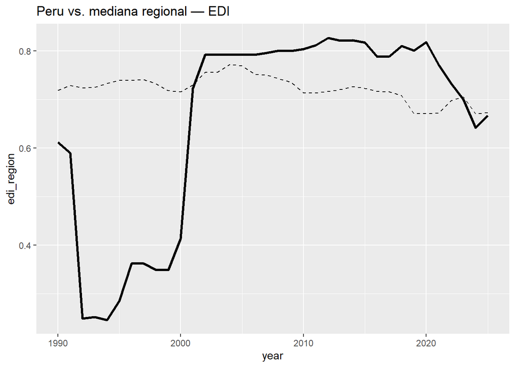

```r
pais_seleccionado <- "Peru"

pais_vs_region <- sudamerica |>
  filter(year >= 1990) |>
  group_by(year) |>
  mutate(edi_region = median(edi, na.rm = TRUE)) |>
  ungroup() |>
  filter(pais == pais_seleccionado)

ggplot(pais_vs_region, aes(x = year)) +
  geom_line(aes(y = edi_region), linetype = "dashed") +
  geom_line(aes(y = edi), linewidth = 1.2) +
  labs(title = paste0(pais_seleccionado, " vs. mediana regional — EDI"))
```

Ahora se nota que la tendencia general de la región para el EDI es bastante estable, oscila entre 0.68 y 0.77 en términos muy generales. Podemos seleccionar varios países para ver cómo fluctúan en torno a la tendencia general.

**Algunos casos interesantes son Venezuela desde los 2000, Bolivia los últimos años, Peru entre los 90 y el 2000. Hacemos, entonces, un gráfico comparando los tres países contra la mediana.**

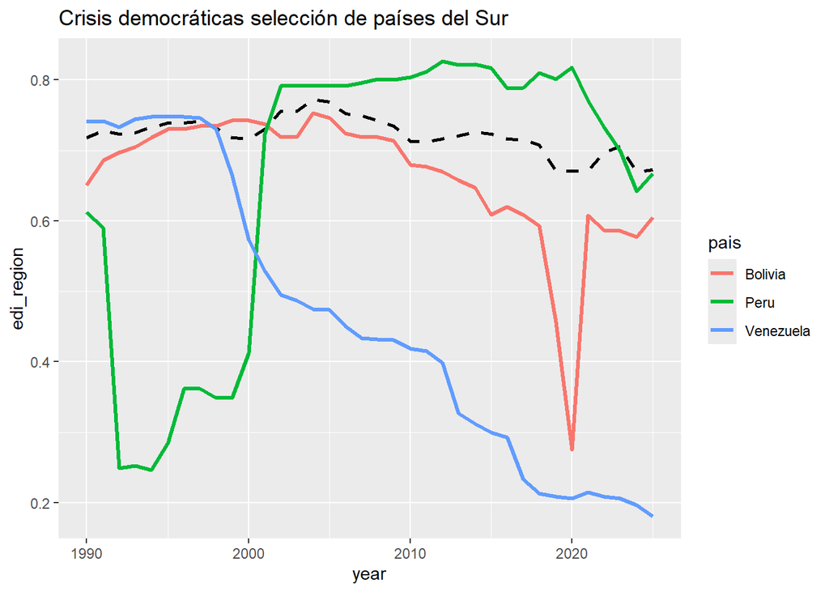

```r
paises_seleccionado <- c("Venezuela", "Bolivia", "Peru")

paises_vs_region <- sudamerica |>
  filter(year >= 1990) |>
  group_by(year) |>
  mutate(edi_region = median(edi, na.rm = TRUE)) |>
  ungroup() |>
  filter(pais %in% paises_seleccionado)

ggplot(paises_vs_region, aes(x = year, color=pais)) +
  geom_line(aes(y = edi_region), color='Black', linetype = "dashed", linewidth = 1) +
  geom_line(aes(y = edi), linewidth = 1.2) +
  labs(title = "Crisis democráticas selección de países del Sur")
```